# College Football and NFL

```r
library(readr)
library(car)
library(corrplot)
library(leaps)
library(Stat2Data)
library(dplyr)
library(tidyr)
library(ggplot2)
library(GGally)
source("ShowSubsets.R")
source("VIF.R")

library(RCurl)

#x <- getURL("https://raw.githubusercontent.com/WeiKangda/Data-Challenge-Football/main/FootballDatasets/NFL/TeamDataBySeason/nfl2000stats.csv")
#NFL2000Full <- read.csv(text = x)
#head(NFL2000Full)
nfl_all_data <- read.csv("nfl_all_data.csv")
head(nfl_all_data)
```

|  | Year | TeamName | Wins | ScoreOff | FirstDown | RushAttOff | RushYdsOff | PassAttOff | PassCompOff | PassYdsOff | PassIntOff | FumblesOff | SackYdsOff | PenYdsOff | PuntAvgOff | ScoreDef | FirstDownDef | RushAttDef | RushYdsDef | PassAttDef | PassCompDef | PassYdsDef | PassIntDef | FumblesDef | SackYdsDef | PenYdsDef |
| --- | --- | --- | --- | --- | --- | --- | --- | --- | --- | --- | --- | --- | --- | --- | --- | --- | --- | --- | --- | --- | --- | --- | --- | --- | --- | --- |
| 1 | 2000 | Arizona Cardinals | 9 | 178 | 253 | 342 | 1284 | 554 | 316 | 3478 | 24 | 20 | 239 | 756 | 710 | 443 | 344 | 580 | 2609 | 458 | 295 | 3263 | 10 | 10 | 126 | 32 |
| 2 | 2000 | Atlanta Falcons | 7 | 238 | 256 | 350 | 1214 | 515 | 285 | 3166 | 20 | 14 | 386 | 720 | 654 | 413 | 308 | 453 | 1983 | 515 | 306 | 3766 | 15 | 10 | 142 | 14 |
| 3 | 2000 | Baltimore Ravens | 12 | 355 | 319 | 619 | 2480 | 553 | 309 | 3539 | 20 | 8 | 349 | 905 | 741 | 181 | 260 | 430 | 1162 | 650 | 357 | 3735 | 29 | 27 | 245 | 39 |
| 4 | 2000 | Buffalo Bills | 8 | 288 | 309 | 476 | 1921 | 546 | 312 | 3936 | 10 | 12 | 359 | 913 | 610 | 350 | 252 | 444 | 1559 | 480 | 283 | 3175 | 16 | 13 | 308 | 27 |
| 5 | 2000 | Carolina Panthers | 7 | 272 | 304 | 363 | 1186 | 566 | 340 | 3850 | 19 | 16 | 382 | 683 | 607 | 310 | 304 | 425 | 1949 | 552 | 352 | 3938 | 17 | 21 | 231 | 38 |
| 6 | 2000 | Chicago Bears | 9 | 216 | 238 | 416 | 1736 | 542 | 304 | 3005 | 16 | 13 | 206 | 696 | 593 | 355 | 297 | 469 | 1828 | 530 | 332 | 3635 | 11 | 9 | 231 | 0 |

```r
cfb_all_data <- read.csv("cfb_all_data.csv")
cfb_all_data <- subset(cfb_all_data, ScoreOff != 0)
head(cfb_all_data)
```

|  | Year | TeamName | Wins | ScoreOff | RushAttOff | RushYdsOff | PassAttOff | PassCompOff | PassYdsOff | PassIntOff | FumblesOff | ScoreDef | RushAttDef | RushYdsDef | PassAttDef | PassCompDef | PassYdsDef | PassIntDef | FumblesDef |
| --- | --- | --- | --- | --- | --- | --- | --- | --- | --- | --- | --- | --- | --- | --- | --- | --- | --- | --- | --- |
| 1 | 2002 | Akron | 4 | 311 | 489 | 1890 | 404 | 265 | 2962 | 12 | 14 | 379 | 492 | 2008 | 340 | 214 | 2726 | 9 | 14 |
| 2 | 2002 | Ball State | 7 | 255 | 499 | 1955 | 348 | 199 | 2144 | 16 | 10 | 333 | 440 | 2035 | 390 | 246 | 2834 | 10 | 23 |
| 3 | 2002 | Bowling Green | 9 | 439 | 500 | 2629 | 398 | 227 | 2758 | 11 | 7 | 297 | 469 | 1844 | 398 | 214 | 2537 | 12 | 51 |
| 4 | 2002 | Connecticut | 5 | 359 | 450 | 1639 | 392 | 232 | 2671 | 12 | 8 | 270 | 459 | 1868 | 322 | 162 | 1925 | 20 | 14 |
| 5 | 2002 | Fresno State | 7 | 332 | 463 | 1668 | 452 | 250 | 3194 | 14 | 10 | 358 | 537 | 2104 | 433 | 245 | 3214 | 13 | 16 |
| 6 | 2002 | Hawaii | 9 | 442 | 286 | 1467 | 679 | 375 | 5043 | 25 | 13 | 353 | 552 | 2218 | 456 | 233 | 2928 | 18 | 32 |

```r
#x <- getURL("https://raw.githubusercontent.com/WeiKangda/Data-Challenge-Football/main/FootballDatasets/CollegeFootball/TeamDataBySeason/cfb2003stats.csv")
#CFB2003Full <- read.csv(text = x)
#CFB2003Full <- subset(CFB2003Full, ScoreOff != 0)
#head(CFB2003Full)
```

1. Predicting wins of an NFL team
1. Correlation between predictors and Full Model with all predictors

```r
#nfl_tr = subset(nfl_all_data, Year != 2013)[3:26]
#nfl_te = subset(nfl_all_data, Year == 2013)[3:26]

nfl_data = nfl_all_data[3:26]

Fullnfl = lm(Wins~., nfl_data)
summary(Fullnfl)
```

```
Call:
lm(formula = Wins ~ ., data = nfl_data)

Residuals:
    Min      1Q  Median      3Q     Max
-5.3121 -1.1823 -0.0084  1.0205  5.2621

Coefficients:
               Estimate Std. Error t value Pr(>|t|)
(Intercept)   1.069e+00  3.013e+00   0.355 0.722925
ScoreOff      1.396e-02  3.175e-03   4.398 1.38e-05 ***
FirstDown     7.533e-03  8.183e-03   0.921 0.357808
RushAttOff    6.002e-03  4.040e-03   1.486 0.138114
RushYdsOff   -1.440e-03  5.703e-04  -2.526 0.011916 *
PassAttOff   -3.551e-03  4.727e-03  -0.751 0.452951
PassCompOff   6.511e-05  6.586e-03   0.010 0.992117
PassYdsOff   -1.269e-04  4.311e-04  -0.294 0.768607
PassIntOff   -2.120e-02  2.236e-02  -0.948 0.343629
FumblesOff    2.516e-02  2.556e-02   0.984 0.325435
SackYdsOff   -2.083e-03  1.388e-03  -1.501 0.134188
PenYdsOff     3.721e-05  6.486e-04   0.057 0.954279
PuntAvgOff    1.917e-03  1.972e-03   0.972 0.331569
ScoreDef     -1.295e-02  3.320e-03  -3.899 0.000112 ***
FirstDownDef -3.233e-03  9.150e-03  -0.353 0.724040
RushAttDef    1.037e-03  4.679e-03   0.222 0.824800
RushYdsDef    9.407e-04  6.139e-04   1.532 0.126188
PassAttDef    1.072e-02  4.977e-03   2.154 0.031798 *
PassCompDef  -6.487e-03  6.467e-03  -1.003 0.316378
PassYdsDef    4.217e-04  4.557e-04   0.925 0.355337
PassIntDef    2.571e-03  2.069e-02   0.124 0.901172
FumblesDef   -1.597e-02  2.617e-02  -0.610 0.541953
SackYdsDef   -1.464e-04  1.798e-03  -0.081 0.935136
PenYdsDef    -2.977e-03  8.905e-03  -0.334 0.738301
---
Signif. codes:  0 ‘***’ 0.001 ‘**’ 0.01 ‘*’ 0.05 ‘.’ 0.1 ‘ ’ 1

Residual standard error: 1.718 on 422 degrees of freedom
Multiple R-squared:  0.4684,    Adjusted R-squared:  0.4394
F-statistic: 16.17 on 23 and 422 DF,  p-value: < 2.2e-16
```

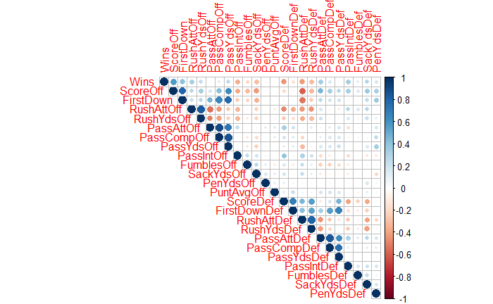

```r
corr = cor(nfl_data, use="pairwise.complete.obs")
corrplot(corr, type="upper")
```

```r
vif(Fullnfl)
```

```
    ScoreOff    FirstDown   RushAttOff   RushYdsOff   PassAttOff  PassCompOff   PassYdsOff   PassIntOff   FumblesOff   SackYdsOff
    7.079632    14.051817     7.226508     5.867960    11.872236    14.434912     9.824538     1.714364     1.391552     1.529516
   PenYdsOff   PuntAvgOff     ScoreDef FirstDownDef   RushAttDef   RushYdsDef   PassAttDef  PassCompDef   PassYdsDef   PassIntDef
    1.423398     1.221156     6.041174    10.594835     7.062549     5.375413     8.293251     7.750347     4.786737     1.649307
  FumblesDef   SackYdsDef    PenYdsDef
    1.410333     1.656283     1.334503
```

```r
#cfb_tr = subset(cfb_all_data, Year != 2013)[3:19]
#cfb_te = subset(cfb_all_data, Year == 2013)[3:19]

#Fullcfb = lm(Wins~., cfb_tr)
#summary(Fullcfb)

#corr = cor(cfb_tr, use="pairwise.complete.obs")
#corrplot(corr, type="upper")

#vif(Fullcfb)
```

We plot the correlation graph of our 23 potential predictors to check if we need to take out possible highly related predictors. (The bigger the circle implies higher correction between the two predictors that have their row and column intersect at that circle) Most of the predictors look in shape, so we will keep all predictors for further subset selection process.

2. Determining number of predictors to include in our model.

2a. Use the regsubsets function from leaps package to perform best subset selection in order to choose the best model containing our 23 predictors according to Cp, BIC, and adjusted R2.

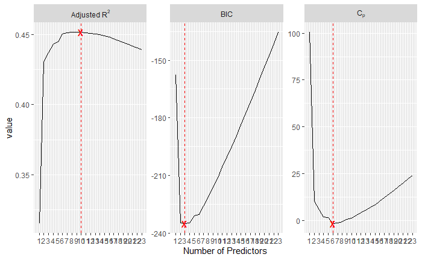

```r
# create datasets for plots
### criteria labels (in plotmath, see expression syntax in ?plotmath)
degree <- 23
model.regsubsets <- summary(regsubsets(Wins ~ ., data = nfl_data, nvmax = degree))

criteria.plotmath <- c(
cp = "C[p]",
bic = "BIC",
adjr2 = "Adjusted~R^2"
)
criteria_names <- c("cp", "bic", "adjr2")
data_plot <- model.regsubsets[criteria_names] %>% data.frame(size = 1:degree) %>%
  gather(cp, bic, adjr2, key = "criteria", value = "value") %>% mutate(criteria_label = criteria.plotmath[criteria])
data_best <- data_plot %>% group_by(criteria) %>% # min of Cp, BIC; max of Adjusted R^2
top_n(1, ifelse(criteria == "adjr2", value, - value))
# generate plots of criteria with respect to the number of predictors
data_plot %>%
ggplot(aes(x = size, y = value)) +
geom_line() +
geom_point(data = data_best, colour = "red", shape = "x", size = 5) +
geom_vline(data = data_best, aes(xintercept = size), colour = "red", linetype = "dashed") +
scale_x_continuous(name = "Number of Predictors", breaks = 1:degree) +
facet_wrap(~ criteria_label, scales = "free_y", labeller = label_parsed)
```

According to Adjusted R^2, our optimal model would have 10 predictors. According to BIC, our optimal model would have 3 predictors. According to Cp, our optimal model would have 6 predictors. Since these subset selection process according to these three criteria do not quite match with each other, we decide to seek for better conclusion considering forward stepwise selection and also using backwards stepwise selection. selection.

2b. Stepwise selection i) Forward Stepwise Selection Method

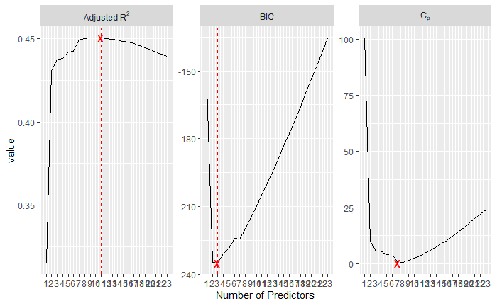

```r
model.regsubsets <- regsubsets(Wins ~ ., data = nfl_data,
method = "forward",
nvmax = degree) %>% summary()

data_plot <- model.regsubsets[criteria_names] %>% data.frame(size = 1:degree) %>%
  gather(cp, bic, adjr2, key = "criteria", value = "value") %>% mutate(criteria_label = criteria.plotmath[criteria])
data_best <- data_plot %>% group_by(criteria) %>% # min of Cp, BIC; max of Adjusted R^2
top_n(1, ifelse(criteria == "adjr2", value, - value))
# generate plots of criteria with respect to the number of predictors
data_plot %>%
ggplot(aes(x = size, y = value)) +
geom_line() +
geom_point(data = data_best, colour = "red", shape = "x", size = 5) +
geom_vline(data = data_best, aes(xintercept = size), colour = "red", linetype = "dashed") +
scale_x_continuous(name = "Number of Predictors", breaks = 1:degree) +
facet_wrap(~ criteria_label, scales = "free_y", labeller = label_parsed)
```

According to Adjusted R^2, our optimal model would have 10 predictors. According to BIC, our optimal model would have 3 predictors. According to Cp, our optimal model would have 7 predictors. The results concluded from forward stepwise method are similar to the results from best subset method. b) Backward Stepwise Selection Method

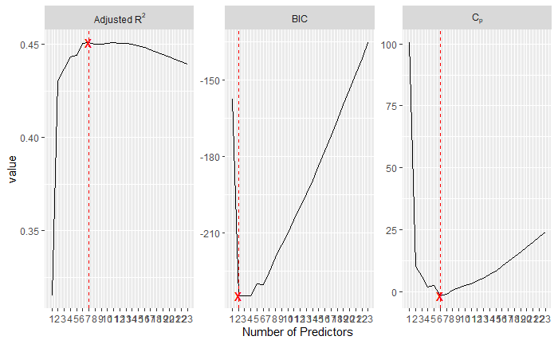

```r
model.regsubsets <- regsubsets(Wins ~ ., data = nfl_data,
method = "backward",
nvmax = degree) %>% summary()

data_plot <- model.regsubsets[criteria_names] %>% data.frame(size = 1:degree) %>%
  gather(cp, bic, adjr2, key = "criteria", value = "value") %>% mutate(criteria_label = criteria.plotmath[criteria])
data_best <- data_plot %>% group_by(criteria) %>% # min of Cp, BIC; max of Adjusted R^2
top_n(1, ifelse(criteria == "adjr2", value, - value))
# generate plots of criteria with respect to the number of predictors
data_plot %>%
ggplot(aes(x = size, y = value)) +
geom_line() +
geom_point(data = data_best, colour = "red", shape = "x", size = 5) +
geom_vline(data = data_best, aes(xintercept = size), colour = "red", linetype = "dashed") +
scale_x_continuous(name = "Number of Predictors", breaks = 1:degree) +
facet_wrap(~ criteria_label, scales = "free_y", labeller = label_parsed)
```